# Adaptive foraging of leaf‐cutter ants to spatiotemporal changes in resource availability in Neotropical savannas - Costa - 2019 - Ecological Entomology - Wiley Online Library

[Ecological Entomology](https://onlinelibrary.wiley.com/journal/13652311)

[Volume 44, Issue 2](https://onlinelibrary.wiley.com/toc/13652311/2019/44/2) p. 227-238

[figure not shown]

Original Article

Full Access

# Adaptive foraging of leaf-cutter ants to spatiotemporal changes in resource availability in Neotropical savannas

[Alan N. Costa](https://onlinelibrary.wiley.com/action/doSearch?ContribAuthorRaw=Costa%2C+Alan+N),

Correspondence: Alan N. Costa, Instituto de Biologia, Universidade Federal de Uberlândia, Av. Pará 1720, 38405-320, Uberlândia, MG, Brazil. E-mail:

[Heraldo L. Vasconcelos](https://onlinelibrary.wiley.com/action/doSearch?ContribAuthorRaw=Vasconcelos%2C+Heraldo+L),

[Ernane H.M. Vieira-Neto](https://onlinelibrary.wiley.com/action/doSearch?ContribAuthorRaw=Vieira-Neto%2C+Ernane+HM),

[Emilio M. Bruna](https://onlinelibrary.wiley.com/action/doSearch?ContribAuthorRaw=Bruna%2C+Emilio+M),

First published: 25 November 2018

https://doi.org/10.1111/een.12697

Citations: 4

Associate Editor: Inge Armbrecht

## Abstract

1. Generalist herbivores feed on a wide and diverse set of species, but fine-scale foraging patterns may be affected by the interplay between the quality, quantity and spatial distribution of host plants.

2. The foraging patterns of a prevalent Neotropical herbivore, the leaf-cutter ant *Atta laevigata*, in the Brazilian Cerrado savannas were examined in order to determine if patterns observed are in concert with central-place foraging predictions.

3. The results showed that *A. laevigata* acts as a polyphagous but highly selective herbivore, with ant attacks often resulting in partial defoliation of less-preferred species and full defoliation of preferred ones. It was found, for the first time, that there is a strong and positive relationship between the relative attack frequency on plants from preferred species and foraging distance to the nest. This suggests a balance between the quality of plant resources harvested and costs involved in their transportation. It was also observed that colonies focused their harvest on preferred species in months with low availability of young leaves. Consequently, high herbivory rate was more frequent in plants attacked far away from the nest and in dry months.

4. These assessments highlight the fact that *Atta* colonies may become more selective as foraging distance to the nest increases and in response to fluctuations in the availability of palatable resources throughout the year. The results also show some dissimilarities in the foraging behaviours of *A. laevigata* when compared with other locations, suggesting that widely distributed herbivores may modify foraging strategies across their geographic range.

## Introduction

Herbivory is a complex and fundamental driver of vegetation dynamics in multiple ecosystems worldwide (Huntly, 1991; Bigger & Marvier, 1998; Kauffman & Maron, 2006). Its complexity stems from the myriad ways in which herbivores interact with their host plants and the surrounding environment. Such interactions are encapsulated by the study of foraging patterns, which represent the behaviours and strategies used by a species to acquire food resources (Pyke, 1984) derived from individual-based decisions (Waldbauer & Friedman, 1991; Scharf *et al*., 2011). Individual choices aim to maximise energy and nutrient intake rates, affecting food selection as well as spatiotemporal search patterns in heterogeneous environments (Illius *et al*., 2002; Simpson *et al*., 2004). While determining foraging patterns for specialist herbivores can be more straightforward, habitat heterogeneity and variability in decision processes are challenges for understanding how generalist herbivores operate in different environments. Although generalist herbivores have the potential to feed on a wide and diverse set of species (Ali & Agrawal, 2012), fine-scale foraging patterns might be affected by the interplay between quality, quantity and spatial distribution of host plants (e.g. Bernays *et al*., 1997; Skarpe *et al*., 2000; Behmer *et al*., 2003). As a result, diet breadth can vary widely, increasing or decreasing based on high-quality plant availability (e.g. Lee *et al*., 2004; Berner *et al*., 2005; Fink & Von Elert, 2006). Such variation can hinder predictions about the impacts of generalist herbivore on the vegetation, particularly for widely distributed species whose foraging patterns have not been assessed throughout their range.

Among the most notable examples of widely distributed generalist herbivores are leaf-cutter ants (Myrmicinae: Attini), conspicuously present from the southern U.S.A. to southern Argentina (Weber, 1966; Farji Brener & Ruggiero, 1994). These ants are regarded as prevalent herbivores in the Neotropics, exerting multiple important effects on their environments (reviewed by Leal *et al*., 2014). Harvested plant parts serve as substrate for growth of a mutualistic fungus, which is the main food source for the colony (De Fine Licht & Boomsma, 2010). As such, ant foragers seek the most suitable plant substrates for growth of their fungus (Saverschek *et al*., 2010). They select plants mainly based on leaf chemical defences or nutrient content (Hubbell & Wiemer, 1983; Howard, 1987, 1988; Mundim *et al*., 2009). Such discrimination regarding quality can occur among and within different plant species, and even among leaves within individual plants (Hubbell & Wiemer, 1983; Meyer *et al*., 2006; Ribeiro Neto *et al*., 2012). These generalisations about leaf-cutter ant-harvesting behaviours have been useful for ecologists to estimate the potential impacts of these insects on plant communities, but are in fact limited because they either do not rely on fine-foraging patterns or have been based on studies carried out with limited species and mainly in forest habitats. For instance, the relatively diverse *Atta* genus (15 described species; Hölldobler & Wilson, 1990) has some species that are narrowly distributed as well as others with a wide geographic range encompassing different biomes. Thus, the extent to which foraging patterns apply to different habitats is still poorly known, as foraging behaviour may vary strongly across and within habitats and species, especially the widely distributed ones (Vasconcelos & Fowler, 1990).

Savanna environments comprise a significant portion of the geographic range of many *Atta* species (Weber, 1966). The largest Neotropical savanna is the Brazilian Cerrado (area *c*. 2 × 10<sup>6</sup> km<sup>2</sup>), a highly heterogeneous, diverse and endangered biome (Myers *et al*., 2000). Stressful conditions in savanna environments (i.e. seasonal precipitation, poor soils and frequent fires) favoured woody plants to develop tougher leaves with lower nutritional value compared with plants typical from forest habitats (Marquis *et al*., 2002). In addition, leaf production is strongly seasonal, with most species producing new leaves for only a few months (Lenza & Klink, 2006; Pirani *et al*., 2009). Given such remarkable differences from forest habitats, it is surprising that, to date, few studies have analysed *Atta* foraging activity in the Cerrado (Schoereder & Coutinho, 1991; Costa *et al*., 2008; Mundim *et al*., 2009, 2012). Therefore, understanding the foraging behaviour of this prominent herbivore in the Brazilian savannas – where their densities average 2.0 nests ha<sup>−1</sup> and increase due to pervasive environmental disturbances (Costa & Vieira-Neto, 2016; Vieira-Neto *et al*., 2016) – is essential to comprehend the potential effects of their consumption on vegetation dynamics.

Adopting the trunk trail system (Lanan, 2014), leaf-cutter ants are emblematic central-place foragers (Orians & Pearson, 1979), with several thousand workers using well-developed physical trails radiating from a central nest to reach host plants dozens or hundreds of metres away and bring back cut material (Kost *et al*., 2005). Therefore, ant foragers have to balance the increased energetic costs of movement and the quality and/or quantity of harvested material when foraging far from nest (Olsson *et al*., 2008). It has been demonstrated that some foraging tasks may be affected by this distance–cost interaction and thus must be adjusted to optimise harvesting rates (Roces, 1990; Burd & Howard, 2005; Farji-Brener *et al*., 2015; Rytter & Shik, 2016). Surprisingly, however, the hypothesis that optimisation may be achieved through an increase in harvesting of better-quality host plants as foraging distance increases has received little attention in studies of leaf-cutter ant foraging behaviour (Bowers & Porter, 1981; Rockwood & Hubbell, 1987), regardless of its importance for the general understanding of their foraging patterns.

Here we present an in-depth evaluation of the foraging activity of *Atta laevigata* (Smith, 1858) leaf-cutter ants in the Brazilian Cerrado savannas. Our goal was to determine their patterns of host plant selection and defoliation rates, as well as how heterogeneity in spatiotemporal plant availability shapes their foraging behaviours and diet breadth. Through these objectives we tested whether: (i) plant species are used by ant colonies independently of their availability in foraging areas; (ii) ant foragers harvest more foliage (i.e. higher herbivory rate) from preferred plant species; and (iii) ant foragers become more selective as a response to spatiotemporal changes in palatable resources, focusing their harvest on preferred plant species when foraging far from the nest.

## Materials and methods

### *Study site*

We conducted our study at Panga Ecological Station (19°10′45″S, 48°23′44″W), a 404-ha reserve located 30 km south of Uberlândia, Minas Gerais, Brazil. The reserve is one of the best-preserved Cerrado remnants in the western Minas Gerais State, harbouring several vegetation types that form a gradient from open savannas to closed forests (Cardoso *et al*., 2009). Our fieldwork was conducted in an area dominated by the *Cerrado denso*, a savanna physiognomy with reduced grass cover and a dense woody layer where tree height reaches *c*. 6 m. The region has a tropical climate with marked dry (May to September) and wet (October to April) seasons, with annual mean temperature and precipitation of 23 °C and 1650 mm, respectively (2003 data from Santa Mônica Climate Station, Uberlândia, MG, Brazil).

### *Data collection*

An attack occurring over subsequent monitoring intervals was considered a single continuous event. Attacks on most plants typically ceased after a few days, although for some large trees and lianas they occasionally lasted for up to 2 months. We only considered a plant re-attacked (i.e. a new attack event) when it had produced new leaves after remaining for a period without being cut. After each attack event was finalised, we recorded plant parts harvested by ants (young and mature leaves, flowers or fruits), estimating the total percentage of plant foliage removed in a semi-quantitative metric scale at 20% intervals (see Morellato *et al*., 2000 for a similar method). In smaller plants (< 3.0 m in height; *c*. 70% of attacked plants), damage estimation was determined directly by counting the number of leaves removed or branches defoliated. For larger trees and lianas, we visually estimated the damage by dividing the canopy into quadrants and counting how many were affected. As the Cerrado vegetation shows a low stand with relatively few trees, it was possible to individualise canopies from large plants and accurately estimate damage. Finally, to determine the linear distance of attacked plants to focal nests, we mapped each individual plant by measuring its distance and angle relative to fixed points in a 10 × 10-m grid established within the colony foraging areas.

To determine the abundance and composition of plant species available to the ants, we established four to six vegetation-sampling plots (1 m wide, 10–25 m long) within foraging areas of each focal colony, positioned 15–20 m apart from each other. As foraging area dimensions varied between focal colonies, we adapted plot number, length, and position to cover most of the foraging areas and better evaluate resource availability throughout; however, we standardised the total area sampled for available resources to 100 m<sup>2</sup> in each foraging area. Within each plot, we recorded the abundance of trees, shrubs, lianas, and herbs (except grasses) taller than 0.3 m. Although plots were not systematically positioned at fixed distances from nests, we were able to estimate the relative availability of resources at increasing distance zones (10-m increments) throughout foraging areas, because at least part of the plots was sampled in each distance zone. Sampling was carried out once at each foraging area between August and November 2003. All plant species were identified with help of specialists and through comparisons with material deposited at the Herbarium Uberlandense (HUFU).

### *Statistical analyses*

The total number of plant species attacked by each colony was compared with the number of available species found within their foraging areas using individual-based rarefaction calculated in estimates v.9.1.0 (Colwell, 2013). We used a non-parametric correlation to determine the relationship between the relative usage of plant species by colonies and their relative availability in foraging areas. In addition, we used a non-metric multidimensional scaling ordination (nMDS) with the Bray–Curtis index of dissimilarity to compare the potential (plants available) and realised (attacked plants) diets of monitored colonies. To determine foraging preferences based on species usage and its correspondent availability, we used an electivity index (EI; Jacobs, 1977), calculated as EI = (*r* − *n*)/( *r* + *n*), where *r* is the proportion of a given species within plants attacked by a colony and *n* is the proportion of this same species within plants available in the foraging area. We classified as preferred those species whose relative use was more than twice their relative availability, and as rejected those that used less than half of the availability. Finally, we used linear regressions to determine the relationship between linear distances from nests and the percentage of preferred species in total plants attacked, as well as the relative availability of preferred species in foraging areas. Analyses were performed in systat v.12 (Systat, 2007).

## Results

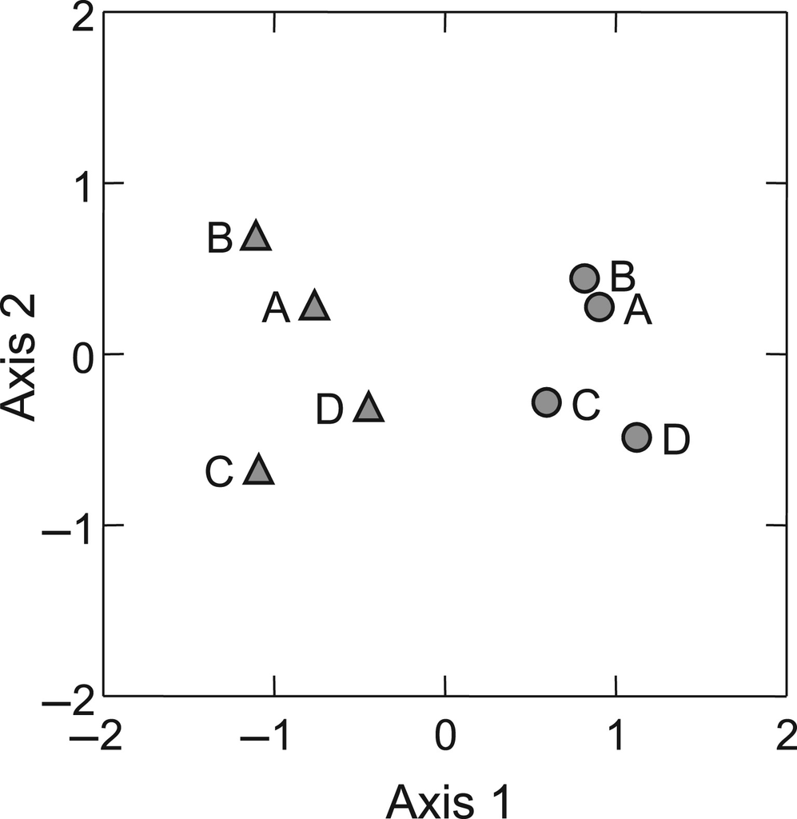

**Figure 1**

Two-dimensional non-metric multidimensional scaling ordination (stress = 0.03479) of the plant species composition comprising potential (plants available, circles) and realised (attacked plants, triangles) diets of four *Atta laevigata* ant colonies (A–D) over 12 months in the Brazilian Cerrado.

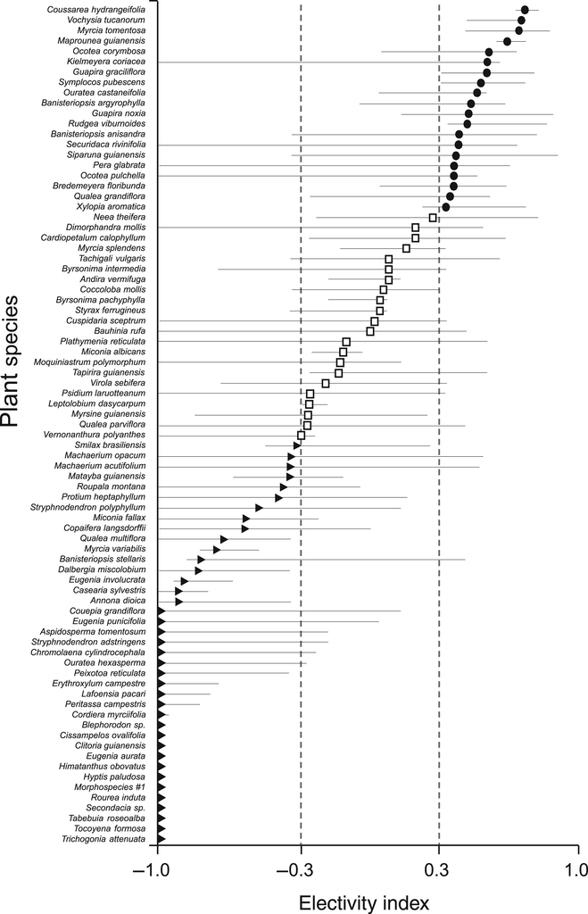

**Figure 2**

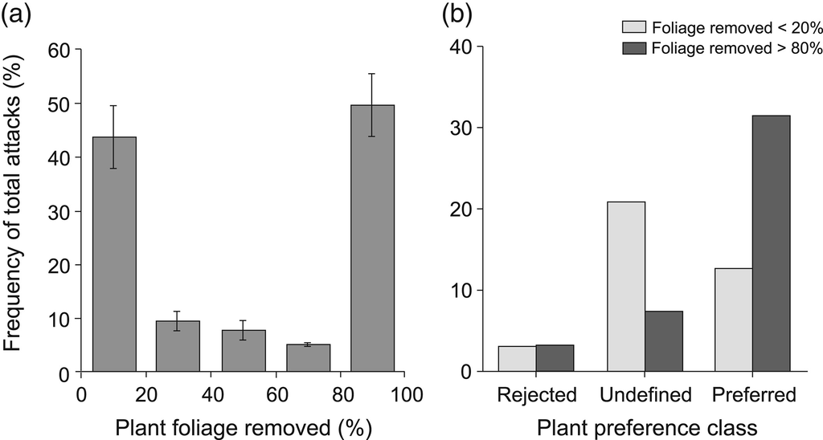

**Figure 3**

Frequency of plants attacked versus foliage removal rates from four ant colonies of *Atta laevigata* over 12 months in the Brazilian Cerrado. (a) Frequency of attacks (mean ± SD) per damage class. (b) Frequency of attacks per preference class of plant species: dark grey, high herbivory rate (foliage removed > 80%); light grey, low herbivory rate (foliage removed < 20%).

Foraging activity was strongly heterogeneous in space around all colonies, with some areas remaining unexplored despite being close to the nests. However, we recorded an increase in the level of electivity among colonies as distance from the nest increased. There was a significant and positive relationship between the proportion of preferred species attacked by colonies and distance from the nest (*r*<sup>2</sup> = 0.670, *F*<sub>1,29</sub> = 58.75, *P* ≤ 0.001; Fig. 4a), whereas their relative abundance did not increase with distance (linear regression, *r*<sup>2</sup> = 0.005, *F*<sub>1,28</sub> = 0.134, *P* = 0.717; Fig. 4b). As preferred plants were frequently completely defoliated and attacks on these species increased far from the nests, the frequency of attacks with high herbivory rates increased significantly with distance from the nest (χ<sub>6</sub><sup>2</sup> = 13.3, *P* < 0.05).

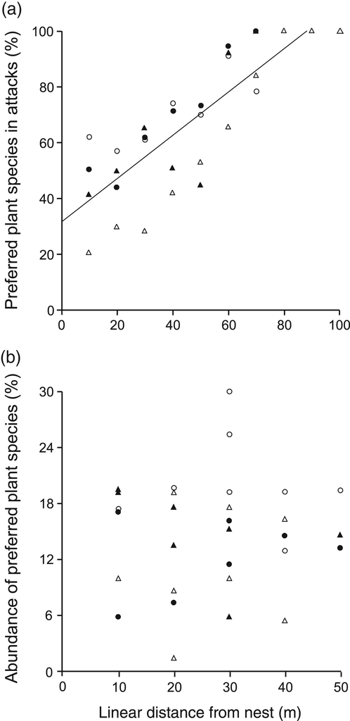

**Figure 4**

Effects of distance from the nest on attacked and available plants within foraging areas of four *Atta laevigata* adult colonies in the Brazilian Cerrado. (a) Relationship between linear distance (LD) from the nest and the percentage of preferred species (PPS) in total plants attacked by ants (PPS = 31.569 + 0.778 × LD; *r*<sup>2</sup> = 0.670, *F*<sub>1,29</sub> = 58.751, *P* ≤ 0.001). (b) Relationship between linear distance from the nest and the relative availability of preferred species throughout the foraging area of these colonies (*r*<sup>2</sup> = 0.005, *F*<sub>1,28</sub> = 0.134, *P* ≤ 0.717). Distinct symbols represent data from different colonies.

Ant colonies attacked a mean of 1.7 plants day<sup>–1</sup> (range = 0.2–6.4) over the 12-month study period. However, we recorded a strong temporal variation in foraging activity (Fig. 5a). Such variation followed the seasonality in rainfall, with more plants attacked during the dry (May–September) than during the wet (October–April) season (*t*<sub>46</sub> = 8.201, *P* ≤ 0.001). In addition, colonies alternated between harvesting new and mature leaves as their monthly dominant plant part (Fig. 5b). Most plant species in the Cerrado reduce or even cease production of new leaves during the dry months, often resuming production in August. Thus, young leaves were more frequently explored at the end of the dry season (September) and throughout the entire wet season, whereas mature leaves were predominantly harvested from May to July. Flowers and fruits were explored during their production peaks between June and December (Fig. 5b). Temporal variation in species selection was affected by the seasonal availability of resources (Fig. 5c). Colonies focused on harvesting mature leaves from preferred species during months of low availability of young leaves, flowers, and fruits. When production of these high-quality items was resumed, colony foraging activity was expanded to some common and even less preferred species. Hence, the level of defoliation on attacked plants varied significantly throughout the year (χ<sub>11</sub><sup>2</sup> = 147.1, *P* ≤ 0.001). Attacks with high herbivory rates occurred more frequently from March to June when preferred plants were the dominant resource explored. From September to January, with increased availability of young leaves in most plant species, attacks with low herbivory rate became more frequent.

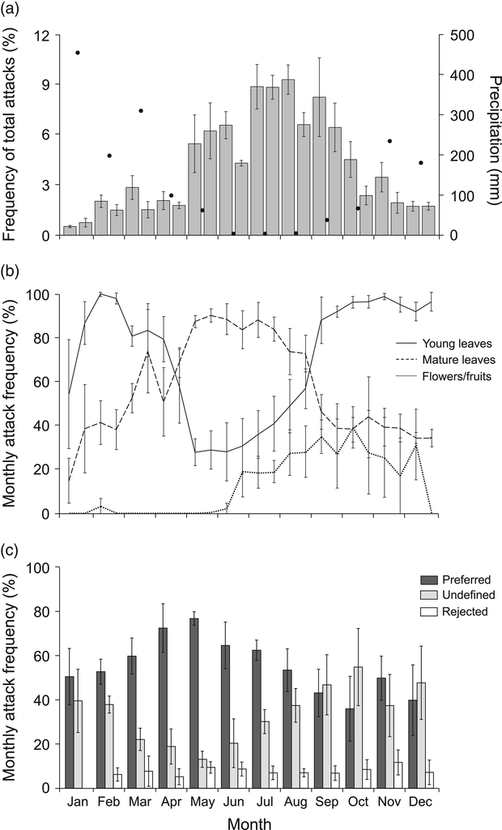

**Figure 5**

Temporal variation in foraging activity (mean ± SD) of four *Atta laevigata* ant colonies over 12 months in the Brazilian Cerrado. (a) Frequency of plants attacked biweekly (bars) and total monthly precipitation (full circles) during the study year (2003). (b) Frequency of plant parts harvested biweekly throughout the year, consisting of young leaves (continuous line), mature leaves (dashed line), and flowers and fruits (dotted line). (c) Frequency of plants attacked from preferred (dark grey), undefined (light grey), and rejected (white) preference classes during the year.

## Discussion

Understanding how generalist herbivores select their host plants and maximise foraging efficiency is an important goal in plant–animal interaction studies. The foraging patterns of leaf-cutter ants, although addressed in previous studies primarily conducted in forests, have continued to elude researchers due to several sources of variation that can affect their selectivity of plant species and even of individuals within species. We investigated the foraging behaviour of *A. laevigata* across space and time, two prominent potential drivers of foraging patterns in heterogeneous and seasonal habitats. We found that *A. laevigata* foraging differs in important ways in the Brazilian Cerrado savannas from that in other locations throughout their range, mainly due to stronger spatiotemporal variation in the availability and distribution of plant resources there (Table 1). Moreover, we quantitatively demonstrate, for the first time, that *Atta* foraging becomes more selective as foraging distance from the nest increases and availability of preferred resources fluctuates throughout the year. These findings highlight important considerations for the study of herbivory and its role in vegetation dynamics.

Table 1. Comparison of the foraging patterns of the leaf-cutter ant *Atta laevigata* between two distant localities within its distributional range: a Neotropical savanna site in central Brazil (this study) and a secondary rain forest in the Brazilian Amazon (Vasconcelos, 1997, 2002).

[output not shown]

- † Numerical data represent total or range of multiple colonies.
- ‡ Ratio between the realised and potential diet diversity. Diet diversity was calculated using the inverse of Simpson's index (Simpson, 1949).

### *Plant selection and herbivory rates*

Leaf-cutter ants are considered generalist herbivores when they attack plant species randomly and in direct proportion to their relative abundance, characterising a fine-grained response to the distribution of resources in the environment. However, they can also act as specialist herbivores by being selective during foraging, thus constituting a coarse-grained response to resource distribution (MacArthur & Pianka, 1966; Pianka, 1974). Our results indicate that *A. laevigata* colonies explore up to 90% of plant species available within their foraging areas, but usage and availability of plant species are unrelated. This coarse-grained foraging response in the Cerrado savanna has previously been suggested as characteristic of different *Atta* species throughout many distinct heterogeneous habitats (Fowler & Stiles, 1980; Vasconcelos & Fowler, 1990). However, a previous study at a regenerating forest showed that plant species usage frequency by *A. laevigata* was positively related to plant abundance (a fine-grained response; Vasconcelos, 1997). Such a difference in foraging patterns within the same ant species in different localities can potentially be explained by the greater abundance of pioneer plants – which are preferred by leaf-cutter ants (Farji-Brener, 2001) – in regenerating forests than in undisturbed savannas. Therefore, a positive relationship between colony diet and plant availability can be expected in places where the most palatable plant species are also the most abundant ones (Vasconcelos, 1997), suggesting that widely distributed leaf-cutter ant species can employ context-dependent foraging strategies (Fowler & Stiles, 1980) depending on resource availability and distribution.

Nonetheless, generalist herbivores often face a trade-off between reducing the consumption of toxic compounds and increasing nutrient intake in their harvest (Behmer *et al*., 2002). Variation in nutritional quality among plant species, individuals and even different parts of the same individual could drive selection patterns and herbivory rates in *Atta* ants, as their harvesting activities are affected by leaf nutrient content (Hubbell & Wiemer, 1983; Howard, 1990; Mundim *et al*., 2009). Our results showed that despite exploring a wide range of species, *A. laevigata* ants act as highly selective herbivores. Plant selection by *A. laevigata* through the EI reflects a potential nutritional-quality gradient of plant species for the mutualistic fungus as their growth substrate. Indeed, species more frequently attacked by *A. laevigata* in Cerrado savannas tend to present higher foliar concentrations of nitrogen than species rarely attacked (Mundim *et al*., 2009). In addition, young expanding leaves represent an item of high nutritional quality in the Cerrado, showing higher concentrations of nutrients than their fully expanded counterparts (i.e. mature or senescent; Varanda *et al*., 2008; Mundim *et al*., 2009; Meloni *et al*., 2012). Accordingly, our results revealed that young leaves were explored in 93% of plant species and harvested by *A. laevigata* colonies whenever available, leading to a bimodal frequency of herbivory rates observed in attacked plants. In 83% of low-damage attacks, ant foraging focused solely on young leaves, although they represented only a portion of available leaves on the plant. Thus, the frequent partial defoliation of host plants by *Atta* is probably due to leaf-quality discrimination performed in each explored plant (Fowler & Stiles, 1980; Hubbell & Wiemer, 1983; Howard, 1990; Meyer *et al*., 2006). Nevertheless, complete or nearly complete defoliation was very common in preferred plant species. However, the relative frequency of high herbivory rates in the Cerrado constituted only half of that observed in regenerating forests (Table 1). Such a difference between locations was probably due to colonies preferentially attacking pioneer species in forest habitats (Farji-Brener, 2001), which tend to be completely or nearly-completely defoliated more frequently (Vasconcelos, 1997).

Leaf-cutter ants exert multiple impacts on the vegetation of Neotropical habitats, acting as herbivores and ecosystem engineers (Leal *et al*., 2014; Farji-Brener & Werenkraut, 2015). Among the positive effects in savanna habitats, seed processing by *Atta* can lead to increments in germination and recruitment (Farji-Brener & Silva, 1996; Leal & Oliveira, 1998; Christianini *et al*., 2007; Christianini & Oliveira, 2009), and nest building enhances plant establishment (Farji-Brener & Silva, 1995; Sosa & Brazeiro, 2010; but see Costa *et al*., 2018). Conversely, seed predation and herbivory negatively affect early recruitment (Ferreira *et al*., 2011; Costa *et al*., 2017) and survival, growth, and reproduction of young and mature plants (Mundim *et al*., 2012). Thus, selective foraging by *A. laevigata* could exert disproportional impacts on preferred species, potentially leading to important alterations in plant assemblages and vegetation dynamics that can be exacerbated by the high densities of leaf-cutter ants in savanna habitats (range: 0.6–4.8 nests ha<sup>–1</sup>; Costa & Vieira-Neto, 2016). Furthermore, natural habitat loss, fragmentation and road opening lead to further increases in leaf-cutter ant populations (Rao, 2000; Wirth *et al*., 2007; Dohm *et al*., 2011; Vieira-Neto *et al*., 2016), resulting in herbivory intensification (Urbas *et al*., 2007; Wirth *et al*., 2007) and, ultimately, in less dense, impoverished and convergent vegetation among disturbed areas (Rao *et al*., 2001; Silva *et al*., 2012). Thus, our results indicate potential negative and long-term impacts of *A. laevigata* foraging on the plant community diversity in natural remnants of the endangered Cerrado, which is currently facing high fragmentation and degradation levels (Carvalho *et al*., 2009).

### *Spatiotemporal foraging patterns*

Most ant species – including leaf-cutters – are central-place foragers (Hölldobler & Wilson, 1990). Such a strategy results in additional costs for food transportation, as foraging trails can radiate more than 100 m away from nests, extending the exposition of ant foragers to predators, sunlight, and rain (Farji-Brener *et al*., 2015), potentially more severely and detrimentally in savannas than in forests, due to less canopy cover in the former. Thus, as distance from the nest increases during foraging, ants should become more selective to maximise the net rate of energy gain (Olsson *et al*., 2008) and minimise exposure to adverse environmental factors. This has been previously suggested, albeit qualitatively, to occur in *A. cephalotes* ants, which forage on higher-quality resources at greater distances from the nest in tropical forests (Rockwood & Hubbell, 1987). Our findings are the first to support quantitatively the hypothesis that leaf-cutter ants become more selective further away from nests, as there was a strong and positive relationship between the attack frequency on preferred plant species and distance from the nests. These results highlight the importance of distance as a factor influencing leaf-cutter ant foraging in open habitats such as Cerrado savannas, as well as the ability of ants to change from fine-grained to coarse-grained responses during local foraging activities. Importantly, we found that the relative abundance of preferred plant species varied randomly throughout foraging areas, which excludes the possibility that the observed pattern is a result of better resources having already been depleted closer to the long-lived nests. In addition to greater selectivity, we observed that herbivory rates also tend to increase with distance from the nest due to frequent high damage of preferred plants species. Hence, the trunk-trail system adopted by leaf-cutter ants (Lanan, 2014) allows them to balance plant-quality harvesting and transportation distance costs to optimise their foraging strategy.

We observed that the foraging rhythm of *A. laevigata* is highly seasonal, a characteristic previously recorded for our focal species (Vasconcelos, 1997, 2002) and observed among other *Atta* species and habitats (Fowler & Robinson, 1979; Wirth *et al*., 1997; Caldato *et al*., 2016; Lopes *et al*., 2016). The number of plants attacked by *A. laevigata* was higher during drier months of the year. We believe this pattern to be a foraging response to increased food demand by the colony due to production of winged individuals in the dry season, which take off for nuptial flights at the beginning of the wet season. Furthermore, selection by *A. laevigata* also varied strongly during the year in the Cerrado, which is potentially explained by the variation in vegetation phenology due to seasonality in leaf, flower and fruit production. Young leaves can be found in the Cerrado year-round, but for most species, production peaks from August to December (Lenza & Klink, 2006; Pirani *et al*., 2009; Silvério & Lenza, 2010). Thus, from March to July, when young leaves became a scarce resource, colonies focused on cutting mature leaves from preferred species, which also led to a greater frequency of high herbivory rates. In the remaining months, less preferred species were more frequently explored by colonies because of the presence of young leaves, flowers and/or fruits to be harvested. Temporal changes in diet breadth were also recorded for *Atta colombica* in wet forests (Shepherd, 1985). However, our results highlight that adjustments in plant selection by leaf-cutter ant colonies may constitute a response to changes in resources availability.

As pointed out previously, leaf-cutter ants may change between coarse and fine-grained responses when foraging in different habitats. Furthermore, Fowler and Stiles (1980) proposed that there are gradual shifts throughout a grain-response continuum as ant colonies often inhabit complex and seasonal environments. Under this assumption, distance- and density-dependent foraging observed in *Atta sexdens* in Paraguay were interpreted as fine-grained responses, with quantity regardless of quality prevailing during their foraging (Fowler & Robinson, 1979). However, our results reveal an opposite pattern for *A. laevigata* in the Brazilian Cerrado. Although we observed that colonies reduced the number of attacked plants when foraging further from nests (similar to *A. sexdens*), they increased selectivity by focusing their harvest on preferred plant species. In addition, we recorded that large flushes of new leaves led colonies to exhibit a temporary generalist behaviour, but they increased selectivity and attacked preferred species more frequently during most of the dry season, when new leaves are scarce, in direct opposition to what has been shown for *A. sexdens*. Therefore, spatiotemporal variation in resource quantity and quality could move their foraging strategy along the coarse- and fine-grained response continuum. Importantly, however, our findings showed that distance- and density-dependent foraging push *A. laevigata* foraging behaviour towards a coarse-grained response.

Our findings show that *A. laevigata* acts as a polyphagous but highly selective herbivore. Young leaves were the main item harvested from less preferred species, which, consequently, were usually only partially defoliated. By contrast, both young and mature leaves were harvested from more palatable preferred species, which accordingly suffered heavy damage. Plant selection and herbivory rate by *A. laevigata* showed a seasonal rhythm following marked changes in plant resource availability. In addition, and in agreement with the central-place foraging theory, we found that colonies became more selective when exploring plant resources far away from their nests, with increased herbivory rates. This suggests that there must be a balance between the quality of plant resources harvested and costs involved in their transportation. Finally, most *A. laevigata* behaviours measured showed differences compared with other locations, indicating that widely distributed herbivores such as some leaf-cutter ant species can modify foraging strategies across their geographic range.

## Acknowledgments

We thank the botanists Glein M. Araújo, Ivan Schiavini, and Jimmy Nakajima for invaluable help identifying plants species. We also thank editors and anonymous reviewers for comments on earlier drafts of this manuscript. This work was supported by fellowships to ANC from the Brazilian Research Council (CNPq, grant no. 104289/02-3) and Minas Gerais Research Foundation (FAPEMIG). Additional financial support was provided by grants from CNPq (grant nos 350046/1995-6 and 470724/2004-8; Project PELD 403733/2012-0 and 441225/2016-0); FAPEMIG (grant no. CRA-703/2004), and the U.S. National Science Foundation (grant no. OISE 0437369). We declare there are no conflicts of interest.

## Citing Literature

[figure not shown]

[Volume44, Issue2](https://onlinelibrary.wiley.com/toc/13652311/2019/44/2)

April 2019

Pages 227-238

### Recommended

  [Alan N. Costa](https://onlinelibrary.wiley.com/action/doSearch?ContribAuthorRaw=Costa%2C+Alan+N), [Heraldo L. Vasconcelos](https://onlinelibrary.wiley.com/action/doSearch?ContribAuthorRaw=Vasconcelos%2C+Heraldo+L), [Emilio M. Bruna](https://onlinelibrary.wiley.com/action/doSearch?ContribAuthorRaw=Bruna%2C+Emilio+M),

  [Heraldo L. Vasconcelos](https://onlinelibrary.wiley.com/action/doSearch?ContribAuthorRaw=Vasconcelos%2C+Heraldo+L), [Antonio B. Casimiro](https://onlinelibrary.wiley.com/action/doSearch?ContribAuthorRaw=Casimiro%2C+Antonio+B),

  [Fabiane M. Mundim](https://onlinelibrary.wiley.com/action/doSearch?ContribAuthorRaw=Mundim%2C+Fabiane+M), [Alan N. Costa](https://onlinelibrary.wiley.com/action/doSearch?ContribAuthorRaw=Costa%2C+Alan+N), [Heraldo L. Vasconcelos](https://onlinelibrary.wiley.com/action/doSearch?ContribAuthorRaw=Vasconcelos%2C+Heraldo+L),

  [Functional Ecology](https://besjournals.onlinelibrary.wiley.com/journal/13652435)

[back](https://onlinelibrary.wiley.com/doi/10.1111/een.12697)